# Statistical Analysis of Ozone Layer Thickness

### Test for Normality

We will test the Box-Cox Transformed data for normality by plotting the QQ Plot and using the Shapiro Test. We have created a function to check normality which plots the qq plot and performs the Shapiro-Wilkins test.

```r
normality_test <- function(transform_used) {
  qq = qqnorm(transform_used, main = 'QQ plot of transformed data')
  qqline(transform_used, col = 2)
  sha = shapiro.test(transform_used)
  return(sha)
}
```

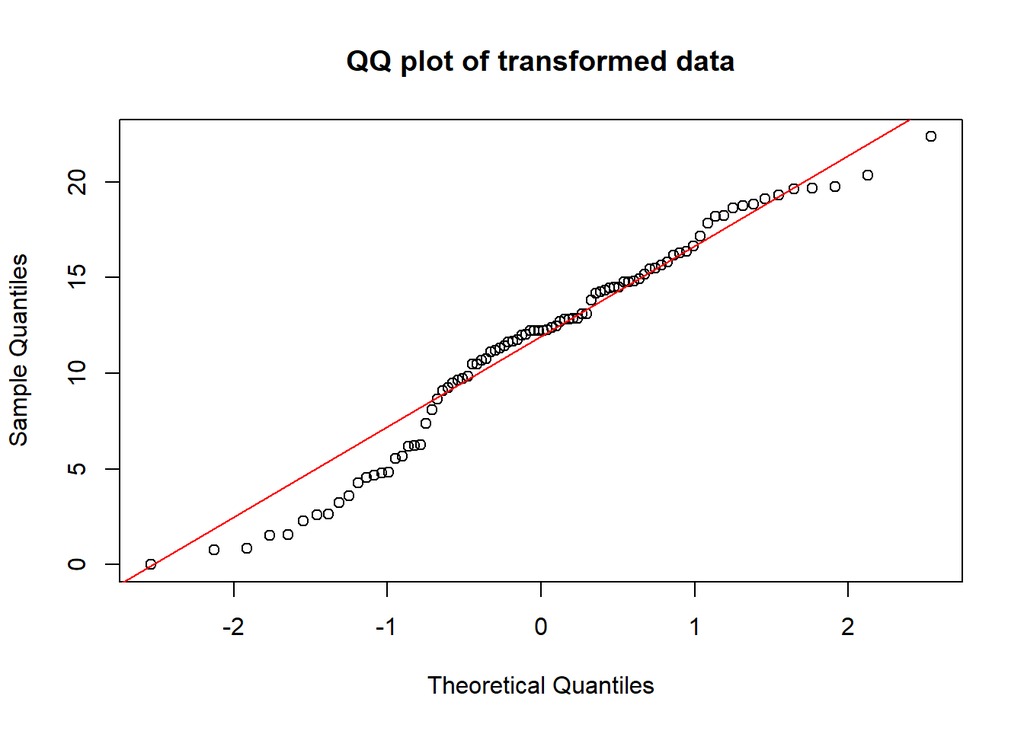

```
##
##  Shapiro-Wilk normality test
##
## data:  transform_used
## W = 0.96644, p-value = 0.01995
```

```r
normality_test(ozonethickness_bc)
```

Conclusion: The qq plot is not normally distributed. The p-value for the Shapiro-Wilkins testis 0.01995, which is less than 0.05. Hence, we reject the null hypothesis of normal distribution. Thus the Box-Cox Transformation was unsucessful to attain normality. We will try the Natural Logarithmic Transformation.

## Natural Logarithmic Transformation

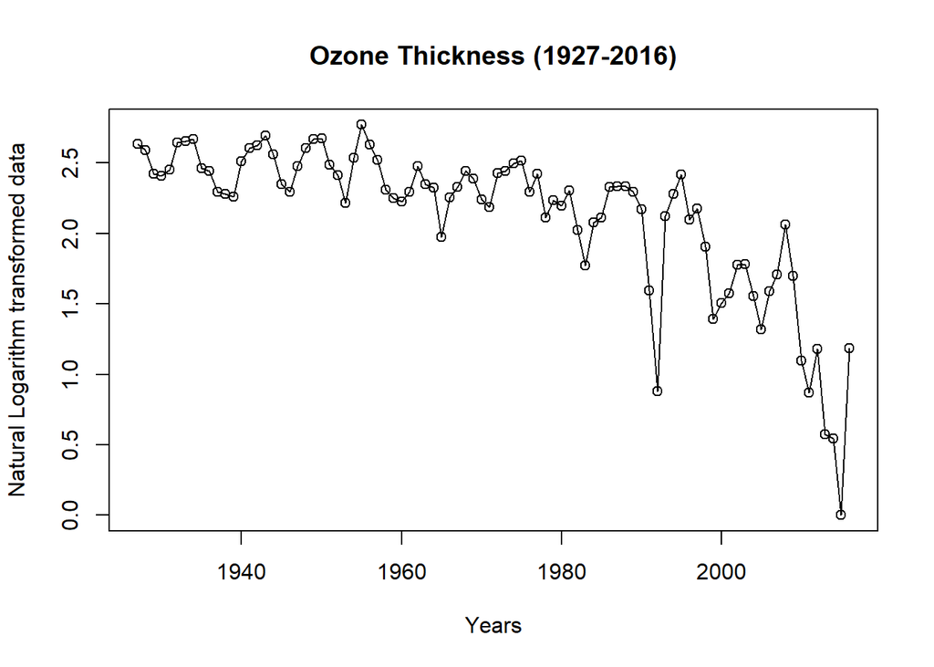

```r
#Creating Logarithm transformed data
ozonethickness_log <- log(ozonethickness_pos)

#Plotting the Logarithm transformed data
plot(ozonethickness_log,
     ylab='Natural Logarithm transformed data',
     xlab="Years",
     type='o',
     main = "Ozone Thickness (1927-2016)")
```

### Test for Normality

We have used the function created above to check for normality

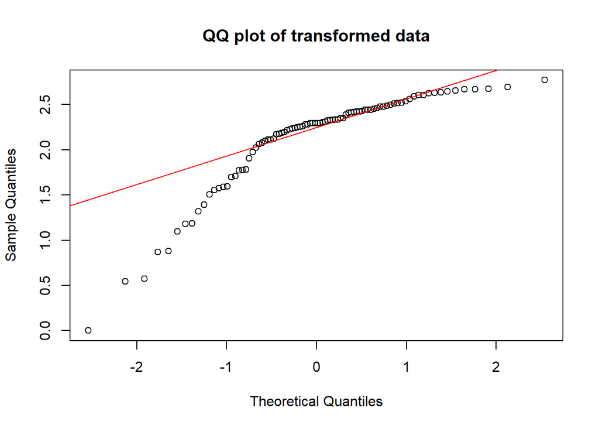

```
##
##  Shapiro-Wilk normality test
##
## data:  transform_used
## W = 0.81905, p-value = 3.949e-09
```

```r
normality_test(ozonethickness_log)
```

Conclusion: The qq plot is not normally distributed. The p-value for the Shapiro-Wilkins testis 3.949e-09, which is less than 0.05. Hence, we reject the null hypothesis of normal distribution. Thus, the Natural Logarithmic Transformation was unsucessful to attain normality.

We will now apply the first difference transformation to the time series data.

## First Order Differencing of the Time Series Data

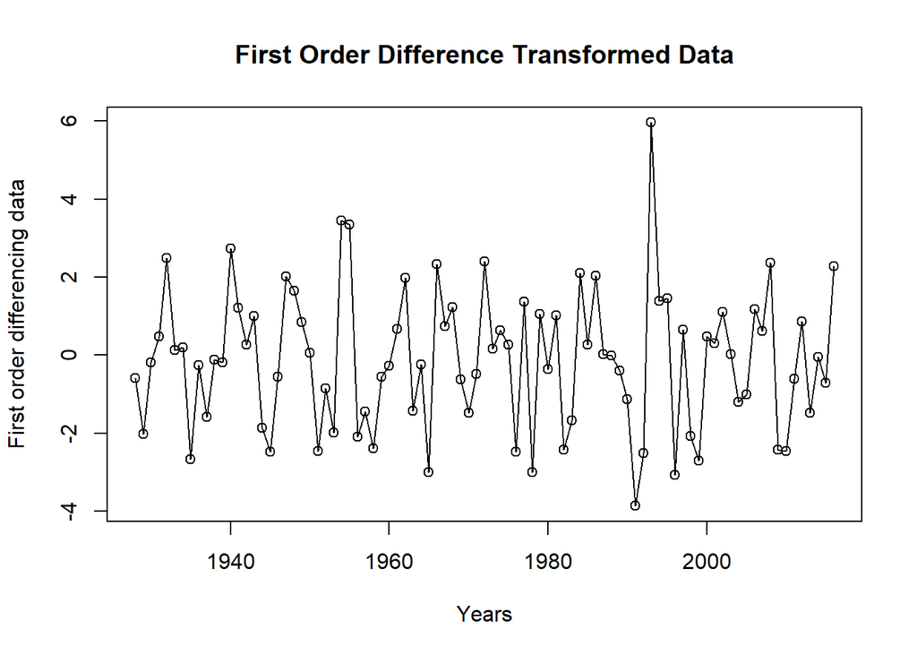

```r
#First Differencing of the Time Series Data
ozonethickness_diff = diff(ozonethickness)

#Plotting the data
plot(ozonethickness_diff,
     type='o',
     ylab='First order differencing data',
     xlab='Years',
     main='First Order Difference Transformed Data')
```

### Dicky Fuller Test

```r
adf.test(ozonethickness_diff)
```

```
##
##  Augmented Dickey-Fuller Test
##
## data:  ozonethickness_diff
## Dickey-Fuller = -7.1568, Lag order = 4, p-value = 0.01
## alternative hypothesis: stationary
```

The Dicky Fuller test gives a p-value smaller than 0.05, hence we can reject the null hypothesis that the series is non-stationary.

### ACF and PACF of First Difference Transform

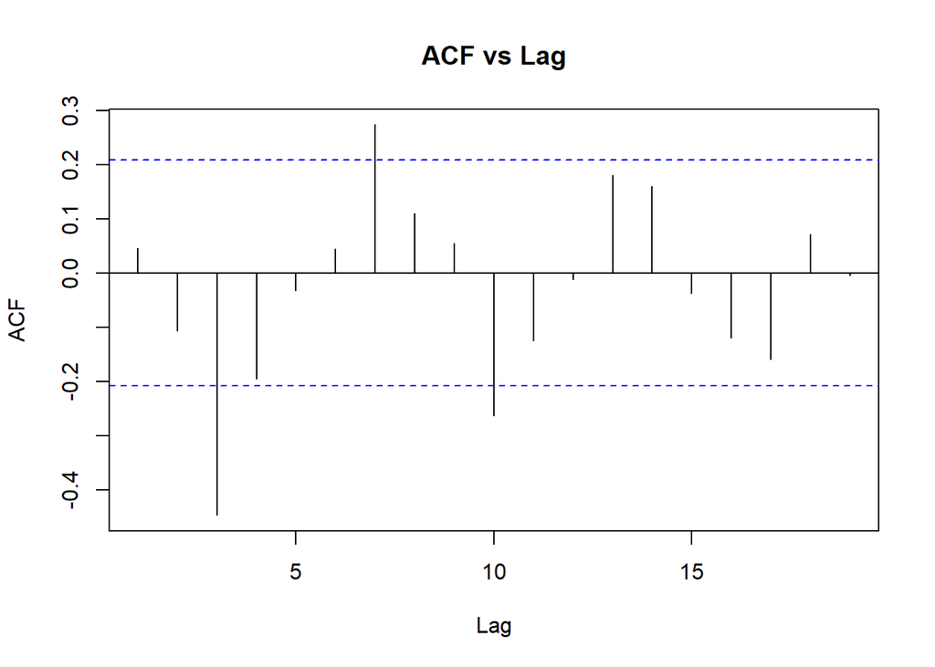

```r
acf(ozonethickness_diff, main='ACF vs Lag')
```

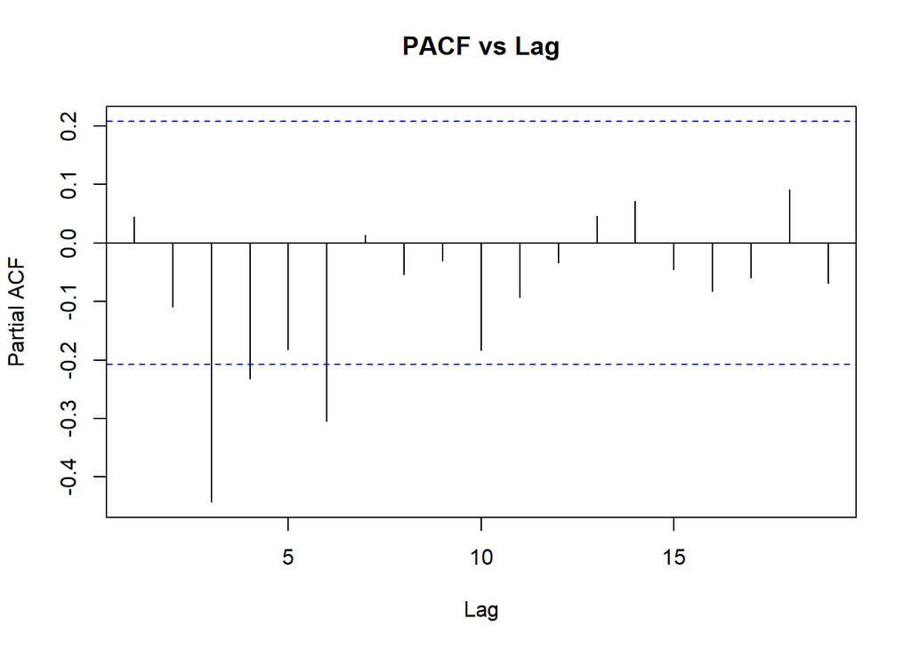

```r
pacf(ozonethickness_diff, main='PACF vs Lag')
```

We can select the value p = 3 from the PACF and the value of q = 3 from ACF. The value of d will be 1 as we have considered the first order difference. Therefore, the possible model is ARIMA(3,1,3).

It can also be said that the models ARMIA(3,1,2), ARMIA(3,1,1), ARMIA(3,1,0), ARMIA(2,1,3), ARMIA(2,1,2), ARMIA(2,1,1), ARMIA(2,1,0), ARMIA(1,1,3), ARMIA(1,1,2), ARMIA(1,1,1), ARMIA(1,1,0), ARMIA(0,1,3), ARMIA(0,1,2), ARMIA(0,1,1) are possible because they are smaller than ARMIA(3,1,3). we can select some of these models only after analyzing them further.

### Extended Autocorellation Function

```r
#Creating the Extended Autocorrelation Function (EACF) model
eacf(ozonethickness_diff)
```

```
## AR/MA
##   0 1 2 3 4 5 6 7 8 9 10 11 12 13
## 0 o o x o o o x o o x o  o  o  o
## 1 x o x o o o o o o x o  o  o  o
## 2 x o x o o o x o o x o  o  o  o
## 3 x o x o o x o o o o o  o  o  o
## 4 x o o x o x o o o o o  o  o  o
## 5 x x x x o x o o o o o  o  o  o
## 6 o o o x x o o o o o o  o  o  o
## 7 o o o x o o o o o o o  o  o  o
```

Here, the value of p = 0,1 and the value of q = 0,1,3,4. The possible models are ARIMA(0,1,1), ARIMA(0,1,3), ARIMA(0,1,4), ARIMA(1,1,0), ARIMA(1,1,3) and ARIMA(1,1,4)

### Bayesian Information Criterion

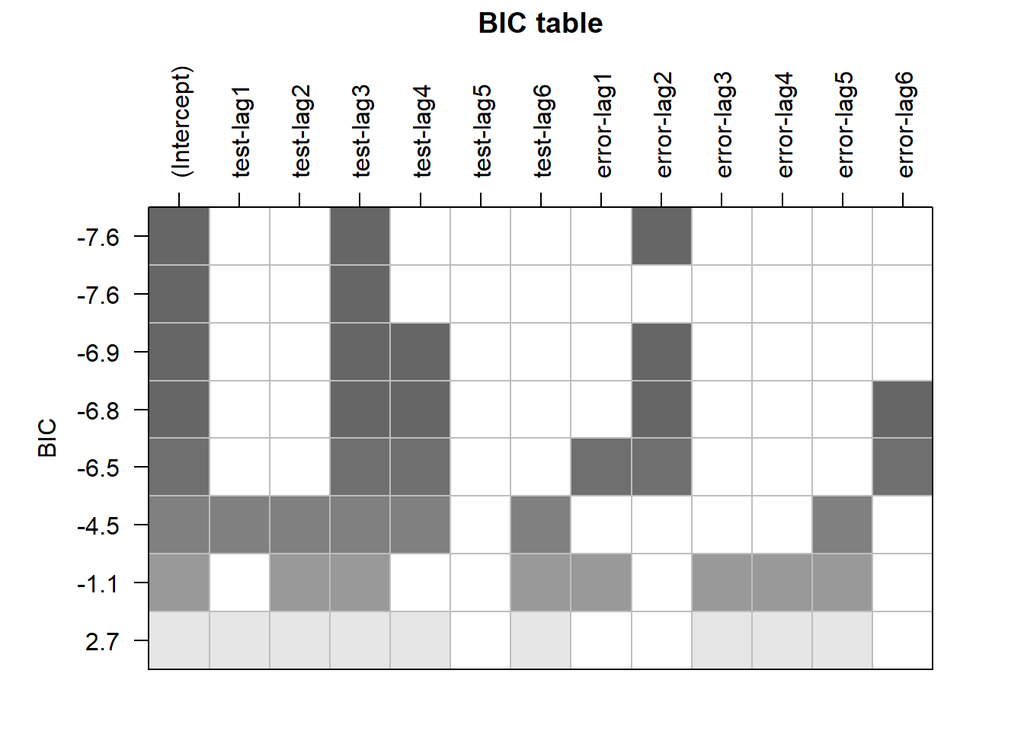

```r
#Plotting the BIC table
plot(armasubsets(y=ozonethickness_diff, nar=6, nma=6, y.name='test', ar.method='ols'))
title(main = 'BIC table', line= 6)
```

The values that can be attained by using the BIC table are p = 3 and q = 2 Hence the possible models are ARIMA(3,1,2) and ARMIA(3,1,0).

# Conclusion

- Task 1:- The best fitted model is the Quadratic Model. The quadratic model was used to forecast the values for the next 5 years. The next five years showed a continuing downward trend in the thickness of the ozone layer.
- Task 2:- The final set of models that can be selected are ARIMA(3,1,3),ARIMA(0,1,1), ARIMA(0,1,3), ARIMA(0,1,4), ARIMA(1,1,0), ARIMA(1,1,3), ARIMA(1,1,4), ARIMA(3,1,2) and ARMIA(3,1,0).

# References

- Time Series Analysis Notes by Dr. Hayder Demirhan
- Bhalla, D., n.d. Regression : Transform Negative Values. [online] ListenData. Available at: https://www.listendata.com/2015/09/regression-transform-negative-values.html [Accessed 16 April 2021].
- Boostedml. 2020. Stationarity and Non-stationary Time Series with Applications in R - Boostedml. [online] Available at: https://boostedml.com/2020/05/stationarity-and-non-stationary-time-series-with-applications-in-r.html#Background [Accessed 16 April 2021].